# PLDI 2014 Survey

J. Vitek, for the SIGPLAN Executive Committee

March 29, 2015

## Population

This survey was conducted in June 2014 by emailing a Google Form to all attendees of PLDI, including the co-located conferences and workshops. There were **275** responses. The respondents were 84% academic. In terms of seniority, 49% self-described as being either a senior researcher or a tenured academic. 50% of respondents work in the USA, the remainder is spread across 28 different countries (the three most represented non-US countries were France, the United Kingdom and Switzerland).

The poll also asked respondent to indicate how many papers they had published at PLDI and how many journal papers they had published.

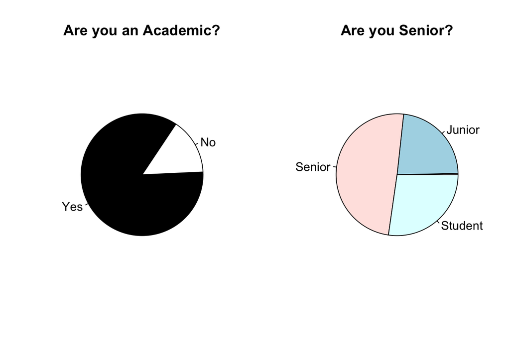

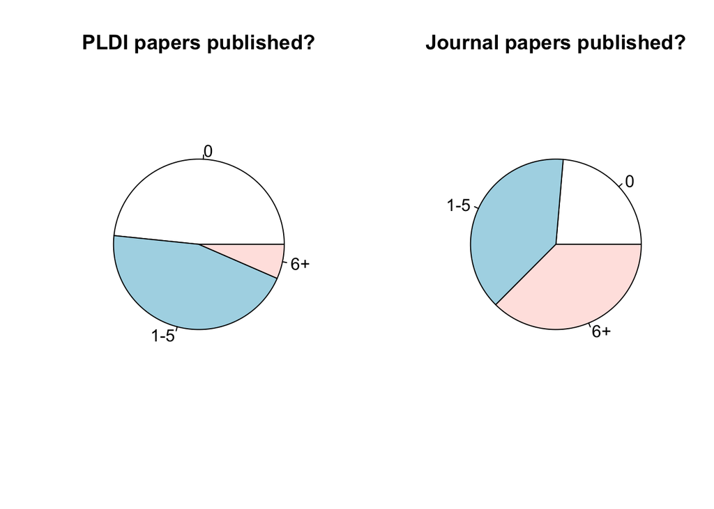

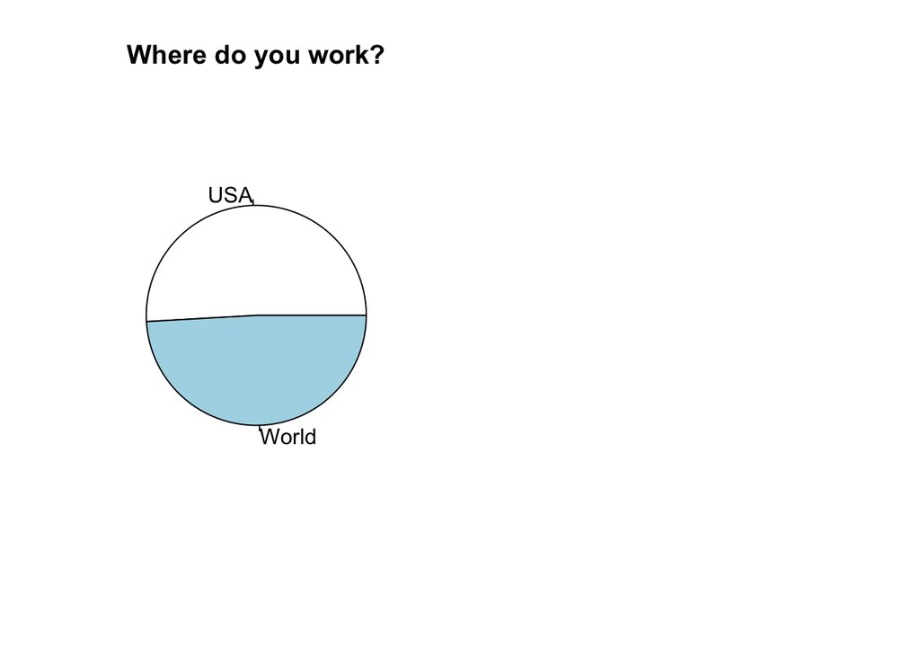

## Publication Venues: Journals or Conferences

The respondents indicate that in 54% of the cases, their employer expects them to publish in journals.

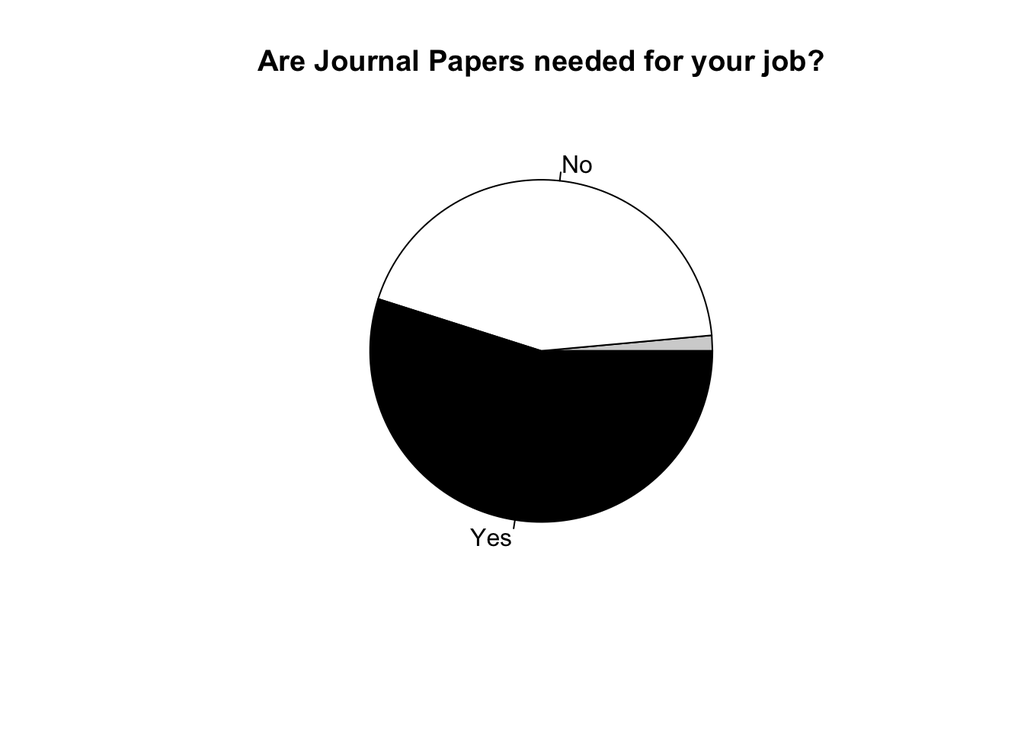

For authors who have never published a journal paper, 60% of them indicate their work does not require them to publish papers. More journal papers are written by authors who feel that this is required by their employer.

There is a marked split in expectations between authors working in the USA and those in the rest of the world. In the USA, 58% of respondent are not expected to publish journal papers, whereas in the rest of the world this number is only 28%. This suggests that employers in the USA have a better understanding of CS publication venues than in the rest of the world.

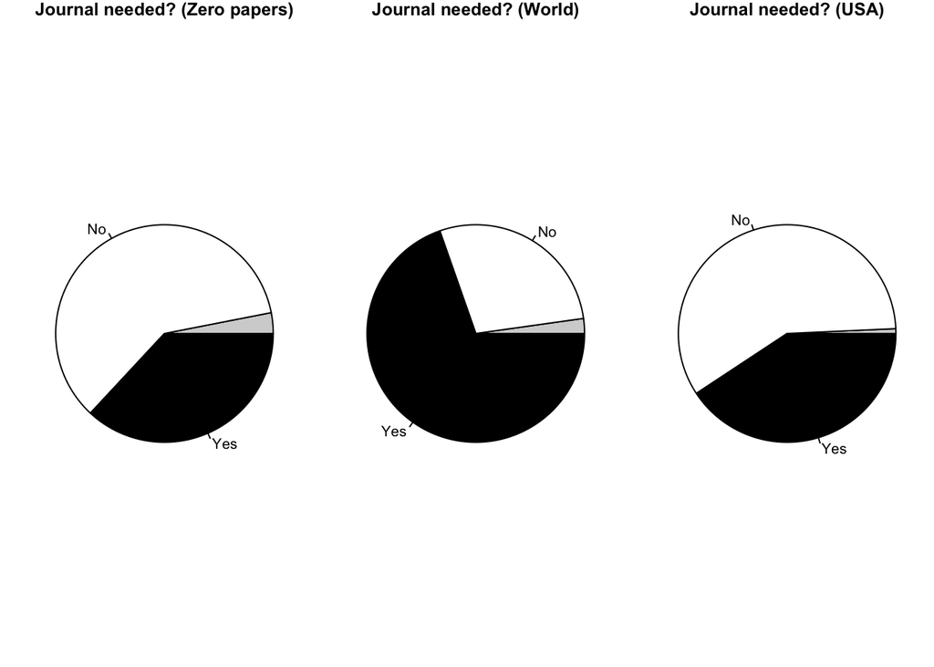

When asked whether they would support publishing the proceedings of PLDI as a special issue of TOPLAS, 70% agreed.

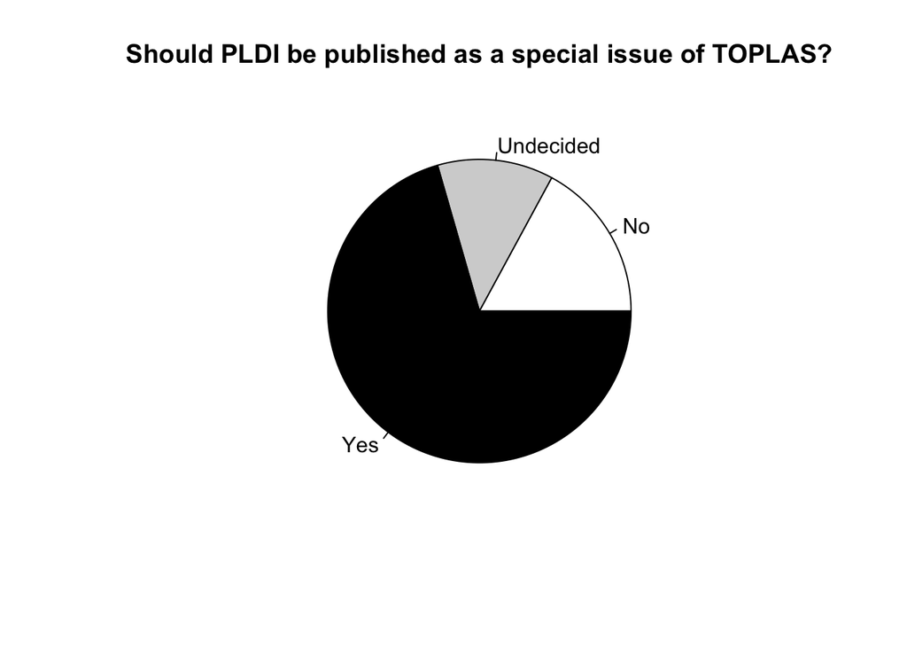

The strenght of the support for this change depends on the country of the respondent and seniority.

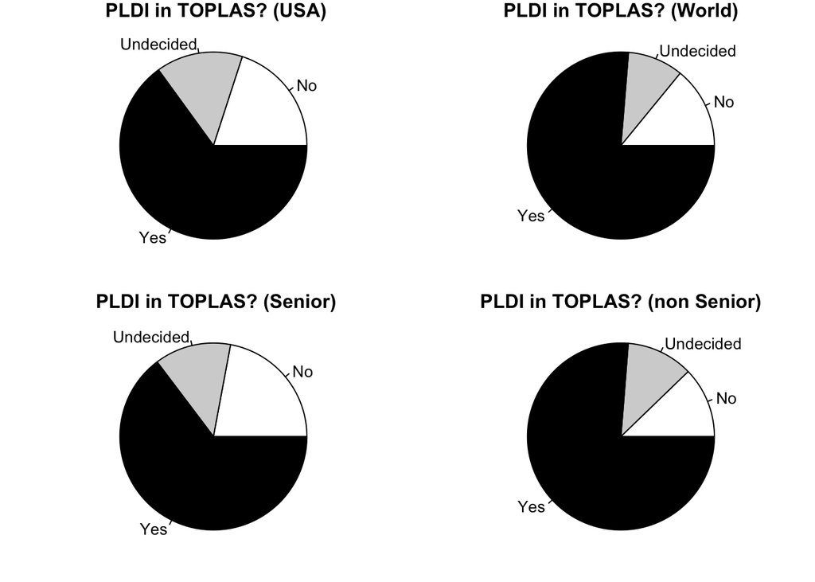

## Open Access

When asked a generic question about their support for open access, 85% are in favor. None was opposed.

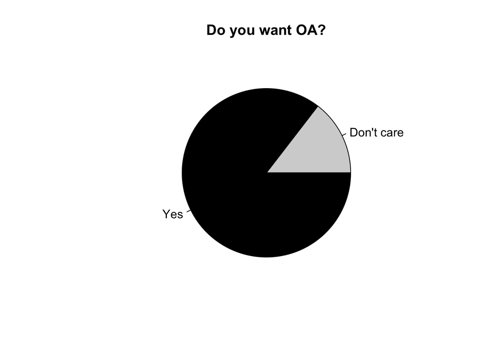

## Comments

The respondents were asked to provide textual comments explaining why they publish in journals.

```
##   [1] In part to fulfill expectations of my department and sometimes (less often) when a paper really would benefit from more details.
##   [2] the papers were rejected from conferences so journals are a second best option
##   [3] When I am unable to fit all essential details into a conference paper
##   [4] I do not, but co-authors sometimes submit journal versions because their universities want this
##   [5] Livelihood
##   [6] long-form writing is nice sometimes
##   [7] can submit any time, less unpredictable outcome
##   [8] (a) looser length constraints let me say what I mean; (b) (less important) CV fodder
##   [9] more space
##  [10] Offer a venue for publishing well-polished comprehensive work without silly page limits.
##  [11] For me, the valuable part about journals is the review process, not the badge that says "journal".
##  [12] Prestige; more careful reviewing; more space to present
##  [13] if there is substantial extension to the conference paper.
##  [14] It's the right thing to do! We shouldn't have to express our ideas in {10,12} pages of sigplanconf.cls.
##  [15] "Full versions" of papers, and extensions of papers that would not make it at top conferences
```

[output cut: 153 more lines]

### Repeatability

A PDF file with questions asked in this poll is [here](http://janvitek.org/who/pldi/survey.pdf).

A CSV file with answers is [here](http://janvitek.org/who/pldi/data.csv.

A PDF file with the Google Form overview of the responses is [here](http://janvitek.org/who/pldi/results.pdf).

The R Markdown code for this document is [here](http://janvitek.org/who/pldi/index.Rmd).